# MITA Capstone Project

```python
import numpy as np
import pandas as pd
import matplotlib.pyplot as plt
import seaborn as sns
%matplotlib inline

import warnings
warnings.filterwarnings("ignore")

import plotly
import plotly.graph_objects as go
import plotly.express as px
import matplotlib.pyplot as plt
```

```python
df=pd.read_csv("/Users/malkani/desktop/project/Ecommerce wish/summer-products-with-rating-and-performance_2020-08.csv")
```

```python
df.head(10)
```

|  | title | title_orig | price | retail_price | currency_buyer | units_sold | uses_ad_boosts | rating | rating_count | rating_five_count | ... | merchant_rating_count | merchant_rating | merchant_id | merchant_has_profile_picture | merchant_profile_picture | product_url | product_picture | product_id | theme | crawl_month |
| --- | --- | --- | --- | --- | --- | --- | --- | --- | --- | --- | --- | --- | --- | --- | --- | --- | --- | --- | --- | --- | --- |
| 0 | 2020 Summer Vintage Flamingo Print Pajamas Se... | 2020 Summer Vintage Flamingo Print Pajamas Se... | 16.00 | 14 | EUR | 100 | 0 | 3.76 | 54 | 26.0 | ... | 568 | 4.128521 | 595097d6a26f6e070cb878d1 | 0 | NaN | https://www.wish.com/c/5e9ae51d43d6a96e303acdb0 | https://contestimg.wish.com/api/webimage/5e9ae... | 5e9ae51d43d6a96e303acdb0 | summer | 2020-08 |
| 1 | SSHOUSE Summer Casual Sleeveless Soirée Party ... | Women's Casual Summer Sleeveless Sexy Mini Dress | 8.00 | 22 | EUR | 20000 | 1 | 3.45 | 6135 | 2269.0 | ... | 17752 | 3.899673 | 56458aa03a698c35c9050988 | 0 | NaN | https://www.wish.com/c/58940d436a0d3d5da4e95a38 | https://contestimg.wish.com/api/webimage/58940... | 58940d436a0d3d5da4e95a38 | summer | 2020-08 |
| 2 | 2020 Nouvelle Arrivée Femmes Printemps et Été ... | 2020 New Arrival Women Spring and Summer Beach... | 8.00 | 43 | EUR | 100 | 0 | 3.57 | 14 | 5.0 | ... | 295 | 3.989831 | 5d464a1ffdf7bc44ee933c65 | 0 | NaN | https://www.wish.com/c/5ea10e2c617580260d55310a | https://contestimg.wish.com/api/webimage/5ea10... | 5ea10e2c617580260d55310a | summer | 2020-08 |
| 3 | Hot Summer Cool T-shirt pour les femmes Mode T... | Hot Summer Cool T Shirt for Women Fashion Tops... | 8.00 | 8 | EUR | 5000 | 1 | 4.03 | 579 | 295.0 | ... | 23832 | 4.020435 | 58cfdefdacb37b556efdff7c | 0 | NaN | https://www.wish.com/c/5cedf17ad1d44c52c59e4aca | https://contestimg.wish.com/api/webimage/5cedf... | 5cedf17ad1d44c52c59e4aca | summer | 2020-08 |
| 4 | Femmes Shorts d'été à lacets taille élastique ... | Women Summer Shorts Lace Up Elastic Waistband ... | 2.72 | 3 | EUR | 100 | 1 | 3.10 | 20 | 6.0 | ... | 14482 | 4.001588 | 5ab3b592c3911a095ad5dadb | 0 | NaN | https://www.wish.com/c/5ebf5819ebac372b070b0e70 | https://contestimg.wish.com/api/webimage/5ebf5... | 5ebf5819ebac372b070b0e70 | summer | 2020-08 |
| 5 | Plus la taille d'été femmes décontracté sans m... | Plus Size Summer Women Casual Sleeveless Rompe... | 3.92 | 9 | EUR | 10 | 0 | 5.00 | 1 | 1.0 | ... | 65 | 3.507692 | 5e4b9c3801ba9d210036fc5a | 0 | NaN | https://www.wish.com/c/5ec645bafd107a02279c8c54 | https://contestimg.wish.com/api/webimage/5ec64... | 5ec645bafd107a02279c8c54 | summer | 2020-08 |
| 6 | Women Fashion Loose Lace Blouse Blouse V Neck ... | Women Fashion Loose Lace Blouse V Neck Bat Sle... | 7.00 | 6 | EUR | 50000 | 0 | 3.84 | 6742 | 3172.0 | ... | 10194 | 4.076516 | 5652f4053a698c76dc9a3f37 | 1 | https://s3-us-west-1.amazonaws.com/sweeper-pro... | https://www.wish.com/c/5c63a337d5e2ce4bbb3152cf | https://contestimg.wish.com/api/webimage/5c63a... | 5c63a337d5e2ce4bbb3152cf | summer | 2020-08 |
| 7 | Robe tunique ample femme Robe d'été Robe en je... | Women's Baggy Tunic Dress Summer Dress Denim D... | 12.00 | 11 | EUR | 1000 | 0 | 3.76 | 286 | 120.0 | ... | 342 | 3.681287 | 5d45349676befe65691dcfbb | 0 | NaN | https://www.wish.com/c/5e0ae5ebc2efb76ccf0a3391 | https://contestimg.wish.com/api/webimage/5e0ae... | 5e0ae5ebc2efb76ccf0a3391 | summer | 2020-08 |
| 8 | Robe d'été décontractée à manches courtes pour... | Women's Summer Casual Dress Fashion Short Slee... | 11.00 | 84 | EUR | 100 | 1 | 3.47 | 15 | 6.0 | ... | 330 | 3.803030 | 5d42980e8388970d32294ddc | 0 | NaN | https://www.wish.com/c/5e6f1fb7fe4a5bb4b8bf36e5 | https://contestimg.wish.com/api/webimage/5e6f1... | 5e6f1fb7fe4a5bb4b8bf36e5 | summer | 2020-08 |
| 9 | Femmes d'été, plus la taille décontractée lâch... | Summer Women Plus Size Casual Loose V Neck Sho... | 5.78 | 22 | EUR | 5000 | 0 | 3.60 | 687 | 287.0 | ... | 5534 | 3.999819 | 5ba2251b4315d12ebce873fa | 0 | NaN | https://www.wish.com/c/5ccfaf238a8d535cec2dfb47 | https://contestimg.wish.com/api/webimage/5ccfa... | 5ccfaf238a8d535cec2dfb47 | summer | 2020-08 |

10 rows × 43 columns

```python
df.columns
```

```
Index(['title', 'title_orig', 'price', 'retail_price', 'currency_buyer',
       'units_sold', 'uses_ad_boosts', 'rating', 'rating_count',
       'rating_five_count', 'rating_four_count', 'rating_three_count',
       'rating_two_count', 'rating_one_count', 'badges_count',
       'badge_local_product', 'badge_product_quality', 'badge_fast_shipping',
       'tags', 'product_color', 'product_variation_size_id',
       'product_variation_inventory', 'shipping_option_name',
       'shipping_option_price', 'shipping_is_express', 'countries_shipped_to',
       'inventory_total', 'has_urgency_banner', 'urgency_text',
       'origin_country', 'merchant_title', 'merchant_name',
       'merchant_info_subtitle', 'merchant_rating_count', 'merchant_rating',
       'merchant_id', 'merchant_has_profile_picture',
       'merchant_profile_picture', 'product_url', 'product_picture',
       'product_id', 'theme', 'crawl_month'],
      dtype='object')
```

From the above columns we can raise few questions like,

1)How different is the 'price' from 'retail price' and what is the effect of the difference. Expecting higher number of units sold if price is less than retail price and vice versa.

2)Does having ad boosts increase success?

3)Any correlation between units sold and ratings?

4)What is badges? This looks like 'awards' of some sort? Do success with increase in number of badges?

5)What are effect of different type of badges?

6)Effect of tags? Higher number of tags results in success?

7)Maybe some brief analysis on product variations.. Do increased variations leads to inreased success?

8)Shipping options analysis

9)Analysis of inventory total and units sold.

10)Merchant detail analysis.. Does merchant rating affect success?

11)What about the details of the merchant? Does not having a profile picture reduce success? Perhaps detailed info leads to higher success?

12)Do all product contains pictures?

```python
df.info()
```

```
<class 'pandas.core.frame.DataFrame'>
RangeIndex: 1573 entries, 0 to 1572
Data columns (total 43 columns):
 #   Column                        Non-Null Count  Dtype
---  ------                        --------------  -----
 0   title                         1573 non-null   object
 1   title_orig                    1573 non-null   object
 2   price                         1573 non-null   float64
 3   retail_price                  1573 non-null   int64
 4   currency_buyer                1573 non-null   object
 5   units_sold                    1573 non-null   int64
 6   uses_ad_boosts                1573 non-null   int64
 7   rating                        1573 non-null   float64
 8   rating_count                  1573 non-null   int64
 9   rating_five_count             1528 non-null   float64
```

[output cut: 35 more lines]

# Preprocessing

```python
df.drop_duplicates(inplace=True)
```

```python
df.isnull().sum()
```

```
title                              0
title_orig                         0
price                              0
retail_price                       0
currency_buyer                     0
units_sold                         0
uses_ad_boosts                     0
rating                             0
rating_count                       0
rating_five_count                 43
rating_four_count                 43
rating_three_count                43
rating_two_count                  43
rating_one_count                  43
badges_count                       0
badge_local_product                0
badge_product_quality              0
badge_fast_shipping                0
tags                               0
product_color                     41
product_variation_size_id         14
product_variation_inventory        0
shipping_option_name               0
shipping_option_price              0
shipping_is_express                0
countries_shipped_to               0
inventory_total                    0
has_urgency_banner              1071
urgency_text                    1071
origin_country                    16
merchant_title                     0
merchant_name                      3
merchant_info_subtitle             1
merchant_rating_count              0
merchant_rating                    0
merchant_id                        0
merchant_has_profile_picture       0
merchant_profile_picture        1314
product_url                        0
product_picture                    0
product_id                         0
theme                              0
crawl_month                        0
dtype: int64
```

### Making product_color simpler and treating its null values

There are 101 colors (see bellow), some of them appear very often while others do not.

One option to deal with this would be to aggregate all the colors into similar groups (for example denimblue goes into blue), to reduce the number of categories.

```python
df['product_color'].unique()
```

```
array(['white', 'green', 'leopardprint', 'black', 'yellow', 'navyblue',
       'blue', 'beige', 'grey', 'lightblue', 'orange', 'red', 'Black',
       'armygreen', nan, 'pink', 'khaki', 'red & blue', 'blue & pink',
       'RED', 'white & green', 'winered', 'black & green', 'purple',
       'whitefloral', 'floral', 'fluorescentgreen', 'orange & camouflage',
       'lightyellow', 'coolblack', 'multicolor', 'camouflage',
       'lightpink', 'pink & black', 'silver', 'Army green', 'lightgreen',
       'mintgreen', 'pink & grey', 'gray', 'coffee', 'rose',
       'light green', 'leopard', 'black & white', 'orange-red',
       'dustypink', 'White', 'star', 'white & black', 'apricot',
       'skyblue', 'burgundy', 'claret', 'pink & white', 'rosered', 'tan',
       'navy blue', 'wine red', 'lightred', 'Pink', 'coralred', 'brown',
       'lakeblue', 'darkblue', 'camel', 'pink & blue', 'nude', 'Blue',
       'lightpurple', 'army', 'black & stripe', 'Rose red',
       'greysnakeskinprint', 'denimblue', 'applegreen', 'offwhite',
       'lightgray', 'navy', 'gray & white', 'brown & yellow',
       'winered & yellow', 'army green', 'whitestripe', 'rainbow',
       'lightgrey', 'watermelonred', 'prussianblue', 'navyblue & white',
       'white & red', 'wine', 'ivory', 'black & yellow', 'jasper',
       'lightkhaki', 'offblack', 'violet', 'black & blue', 'blackwhite',
       'darkgreen', 'rosegold', 'gold'], dtype=object)
```

```python
color_df = df['product_color'].value_counts()
color_df = color_df.reset_index()
color_df.head(15)
```

|  | index | product_color |
| --- | --- | --- |
| 0 | black | 298 |
| 1 | white | 246 |
| 2 | yellow | 101 |
| 3 | pink | 97 |
| 4 | blue | 96 |
| 5 | red | 92 |
| 6 | green | 86 |
| 7 | grey | 70 |
| 8 | purple | 53 |
| 9 | armygreen | 31 |
| 10 | orange | 27 |
| 11 | navyblue | 27 |
| 12 | winered | 27 |
| 13 | multicolor | 20 |
| 14 | beige | 14 |

```python
df['product_color'] = df['product_color'].replace('Black', 'black')
df['product_color'] = df['product_color'].replace('White', 'white')

df['product_color'] = df['product_color'].replace('navyblue', 'blue')
df['product_color'] = df['product_color'].replace('lightblue', 'blue')
df['product_color'] = df['product_color'].replace('skyblue', 'blue')
df['product_color'] = df['product_color'].replace('darkblue', 'blue')
df['product_color'] = df['product_color'].replace('navy', 'blue')

df['product_color'] = df['product_color'].replace('winered', 'red')
df['product_color'] = df['product_color'].replace('rosered', 'red')
df['product_color'] = df['product_color'].replace('rose', 'red')
df['product_color'] = df['product_color'].replace('orange-red', 'red')
df['product_color'] = df['product_color'].replace('lightpink', 'pink')

df['product_color'] = df['product_color'].replace('armygreen', 'green')
df['product_color'] = df['product_color'].replace('khaki', 'green')
df['product_color'] = df['product_color'].replace('lightgreen', 'green')
df['product_color'] = df['product_color'].replace('fluorescentgreen', 'green')

df['product_color'] = df['product_color'].replace('gray', 'grey')

df['product_color'] = df['product_color'].replace('coffee', 'brown')

df['product_color'] = df['product_color'].replace('multicolor', 'other')
df['product_color'] = df['product_color'].replace('floral', 'other')
df['product_color'] = df['product_color'].replace('leopardprint', 'other')
df['product_color'] = df['product_color'].replace('camouflage', 'other')
df['product_color'] = df['product_color'].replace('white & green', 'dual')
df['product_color'] = df['product_color'].replace('black & green', 'dual')
df['product_color'] = df['product_color'].replace('black & white', 'dual')
df['product_color'] = df['product_color'].replace('camouflage', 'other')
df['product_color'] = df['product_color'].replace('beige', 'other')
df['product_color'] = df['product_color'].replace('red & blue', 'dual')
df['product_color'] = df['product_color'].replace('blue & pink', 'dual')
df['product_color'] = df['product_color'].replace('RED', 'red')
df['product_color'] = df['product_color'].replace('whitefloral', 'other')
df['product_color'] = df['product_color'].replace('orange & camouflage', 'other')
df['product_color'] = df['product_color'].replace('lightyellow', 'yellow')
df['product_color'] = df['product_color'].replace('pink & black', 'dual')
df['product_color'] = df['product_color'].replace('Army green', 'green')
df['product_color'] = df['product_color'].replace('mintgreen', 'green')
df['product_color'] = df['product_color'].replace('pink & gray', 'dual')
df['product_color'] = df['product_color'].replace('light green', 'green')
df['product_color'] = df['product_color'].replace('leopard', 'other')
df['product_color'] = df['product_color'].replace('dustypink', 'pink')
df['product_color'] = df['product_color'].replace('star', 'other')
df['product_color'] = df['product_color'].replace('white & black', 'dual')
df['product_color'] = df['product_color'].replace('apricot', 'other')
df['product_color'] = df['product_color'].replace('claret', 'other')
df['product_color'] = df['product_color'].replace('pink & white', 'dual')
df['product_color'] = df['product_color'].replace('rosered', 'red')
df['product_color'] = df['product_color'].replace('tan', 'brown')
df['product_color'] = df['product_color'].replace('lakeblue', 'blue')
df['product_color'] = df['product_color'].replace('wine red', 'red')
df['product_color'] = df['product_color'].replace('navy blue', 'blue')
df['product_color'] = df['product_color'].replace('lightred', 'red')
df['product_color'] = df['product_color'].replace('Pink', 'pink')
df['product_color'] = df['product_color'].replace('coralred', 'red')
df['product_color'] = df['product_color'].replace('pink & blue', 'dual')
df['product_color'] = df['product_color'].replace('Blue', 'blue')
df['product_color'] = df['product_color'].replace('lightpurple', 'purple')
df['product_color'] = df['product_color'].replace('army', 'other')
df['product_color'] = df['product_color'].replace('black & stripe', 'dual')
df['product_color'] = df['product_color'].replace('Rose red', 'red')
df['product_color'] = df['product_color'].replace('greysnakeskinprint', 'other')
df['product_color'] = df['product_color'].replace('denimblue', 'blue')
df['product_color'] = df['product_color'].replace('applegreen', 'green')
df['product_color'] = df['product_color'].replace('offwhite', 'white')
df['product_color'] = df['product_color'].replace('lightgrey', 'grey')
df['product_color'] = df['product_color'].replace('lightgray', 'grey')
df['product_color'] = df['product_color'].replace('gray and white', 'dual')
df['product_color'] = df['product_color'].replace('brown & yellow', 'dual')
df['product_color'] = df['product_color'].replace('winered & yellow', 'dual')
df['product_color'] = df['product_color'].replace('whitestripe', 'white')
df['product_color'] = df['product_color'].replace('watermelonred', 'red')
df['product_color'] = df['product_color'].replace('prussianblue', 'blue')
df['product_color'] = df['product_color'].replace('navyblue & white', 'dual')
df['product_color'] = df['product_color'].replace('white and red', 'dual')
df['product_color'] = df['product_color'].replace('black & yellow', 'dual')
df['product_color'] = df['product_color'].replace('wine', 'red')
df['product_color'] = df['product_color'].replace('jasper', 'other')
df['product_color'] = df['product_color'].replace('lightkhaki', 'green')
df['product_color'] = df['product_color'].replace('offblack', 'black')
df['product_color'] = df['product_color'].replace('black & blue', 'dual')
df['product_color'] = df['product_color'].replace('blackwhite', 'dual')
df['product_color'] = df['product_color'].replace('darkgreen', 'green')
df['product_color'] = df['product_color'].replace('rosegold', 'gold')





df['product_color'] = df['product_color'].replace(np.nan, 'other')

pr_colr = df['product_color'].value_counts()
pr_colr[pr_colr > 2]
```

```
black     302
white     251
blue      159
red       145
green     144
pink      105
yellow    103
other      98
grey       82
purple     54
dual       36
orange     27
brown      14
Name: product_color, dtype: int64
```

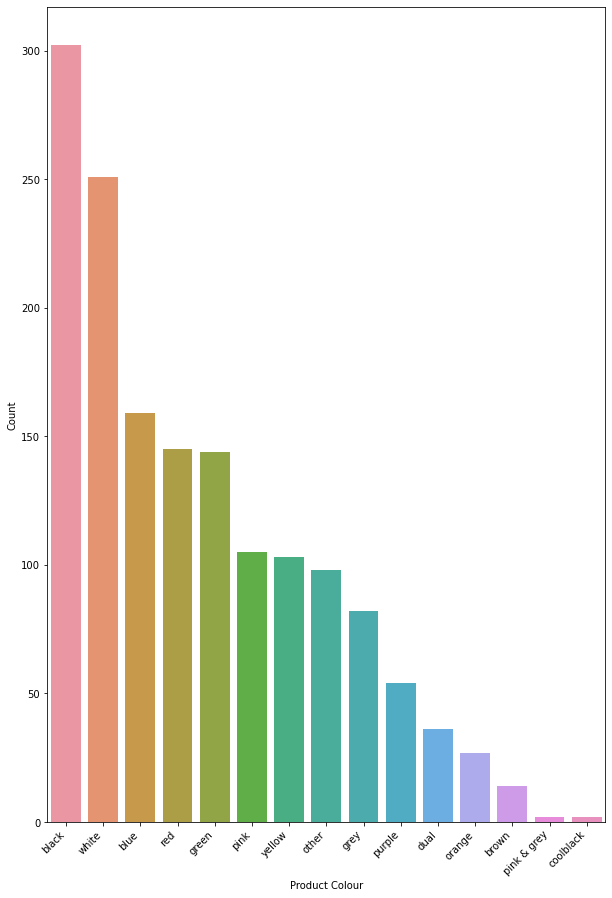

```python
fig_dims = (10, 15)
fig, ax = plt.subplots(figsize=fig_dims)
sns.countplot('product_color',
              data = df,
              order = df['product_color'].value_counts().iloc[:15].index,
              ax = ax)
ax.set(xlabel='Product Colour', ylabel='Count')
plt.xticks(rotation=45, ha='right')
plt.show()
```

```python
df['product_color'] = df['product_color'].replace(np.nan, 'other')
df.isnull().any()
```

```
title                           False
title_orig                      False
price                           False
retail_price                    False
currency_buyer                  False
units_sold                      False
uses_ad_boosts                  False
rating                          False
rating_count                    False
rating_five_count                True
rating_four_count                True
rating_three_count               True
rating_two_count                 True
rating_one_count                 True
badges_count                    False
badge_local_product             False
badge_product_quality           False
badge_fast_shipping             False
tags                            False
product_color                   False
product_variation_size_id        True
product_variation_inventory     False
shipping_option_name            False
shipping_option_price           False
shipping_is_express             False
countries_shipped_to            False
inventory_total                 False
has_urgency_banner               True
urgency_text                     True
origin_country                   True
merchant_title                  False
merchant_name                    True
merchant_info_subtitle           True
merchant_rating_count           False
merchant_rating                 False
merchant_id                     False
merchant_has_profile_picture    False
merchant_profile_picture         True
product_url                     False
product_picture                 False
product_id                      False
theme                           False
crawl_month                     False
dtype: bool
```

### Origin Country

The great majority of the dataset has origin in CN.

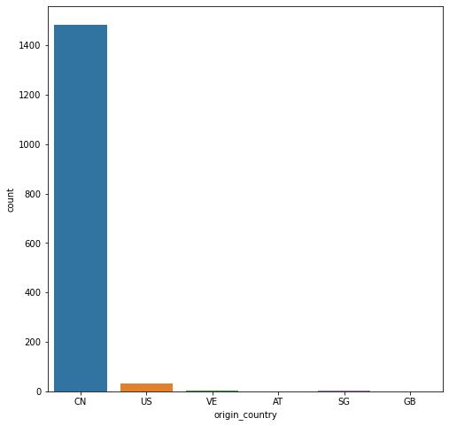

```python
fig_dims = (8, 8)
fig, ax = plt.subplots(figsize=fig_dims)
sns.countplot('origin_country',
              data = df,
              ax = ax)
```

China and US are the prominent countries. Since other countries have less contribution for the set, those items were replaced with 'Other'

```python
df['origin_country'] = df['origin_country'].replace(np.nan, 'Other')
df['origin_country'] = df['origin_country'].replace('VE', 'Other')
df['origin_country'] = df['origin_country'].replace('SG', 'Other')
df['origin_country'] = df['origin_country'].replace('AT', 'Other')
df['origin_country'] = df['origin_country'].replace('GB', 'Other')
```

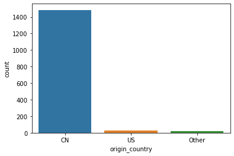

```python
sns.countplot('origin_country',
              data = df)
```

### Simplify product_variation_size_id and treat null values

lot of these sizes are from different scales, so I need to convert them to the same scale.

```python
df["product_variation_size_id"].unique()
```

```
array(['M', 'XS', 'S', 'Size-XS', 'M.', 'XXS', 'L', 'XXL', nan, 'S.', 's',
       'choose a size', 'XS.', '32/L', 'Suit-S', 'XXXXXL', 'EU 35', '4',
       'Size S.', '1m by 3m', '3XL', 'Size S', 'XL', 'Women Size 36',
       'US 6.5 (EU 37)', 'XXXS', 'SIZE XS', '26(Waist 72cm 28inch)',
       'Size XXS', '29', '1pc', '100 cm', 'One Size', 'SIZE-4XL', '1',
       'S/M(child)', '2pcs', 'XXXL', 'S..', '30 cm', '5XL', '33',
       'Size M', '100 x 100cm(39.3 x 39.3inch)', '100pcs', '2XL', '4XL',
       'SizeL', 'SIZE XXS', 'XXXXL', 'Base & Top & Matte Top Coat',
       'size S', '35', '34', 'SIZE-XXS', 'S(bust 88cm)',
       'S (waist58-62cm)', 'S(Pink & Black)', '20pcs', 'US-S',
       'Size -XXS', 'X   L', 'White', '25', 'Size-S', 'Round',
       'Pack of 1', '1 pc.', 'S Diameter 30cm', '6XL',
       'AU plug Low quality', '5PAIRS', '25-S', 'Size/S', 'S Pink',
       'Size-5XL', 'daughter 24M', '2', 'Baby Float Boat', '10 ml', '60',
       'Size-L', 'US5.5-EU35', '10pcs', '17', 'Size-XXS', 'Women Size 37',
       '3 layered anklet', '4-5 Years', 'Size4XL', 'first  generation',
       '80 X 200 CM', 'EU39(US8)', 'L.', 'Base Coat', '36', '04-3XL',
       'pants-S', 'Floating Chair for Kid', '20PCS-10PAIRS', 'B',
       'Size--S', '5', '1 PC - XL', 'H01', '40 cm', 'SIZE S'],
      dtype=object)
```

```python
sizes_df=df['product_variation_size_id'].value_counts()
sizes_df=sizes_df.reset_index()
sizes_df.head(15)
```

|  | index | product_variation_size_id |
| --- | --- | --- |
| 0 | S | 630 |
| 1 | XS | 344 |
| 2 | M | 198 |
| 3 | XXS | 94 |
| 4 | L | 49 |
| 5 | XL | 17 |
| 6 | S. | 16 |
| 7 | XXL | 15 |
| 8 | XXXS | 6 |
| 9 | Size S | 5 |
| 10 | XS. | 5 |
| 11 | s | 5 |
| 12 | 4XL | 5 |
| 13 | 2XL | 4 |
| 14 | M. | 4 |

```python
product_size_convert_dict = {
         'M':'M', 'XS':'XS', 'S':'S', 'Size-XS':'XS', 'M.':'M',
         'XXS':'XXS', 'L':'L', 'XXL':'XXL','S.':'S',
         's':'S','choose a size':'other', 'XS.':'XS', '32/L':'L',
         'Suit-S':'S', 'XXXXXL':'other', 'EU 35':'S',
         '4':'other','Size S.':'S', '1m by 3m':'other', '3XL':'other',
         'Size S':'S', 'XL':'XL', 'Women Size 36':'S',
         'US 6.5 (EU 37)':'M', 'XXXS':'other', 'SIZE XS':'XS',
         '26(Waist 72cm 28inch)':'M','Size XXS':'XXS',
         '29':'other', '1pc':'other', '100 cm':'other',
         'One Size':'other', 'SIZE-4XL':'other', '1':'other',
         'S/M(child)':'other', '2pcs':'other', 'XXXL':'other',
         'S..':'S', '30 cm':'L', '5XL':'other', '33':'S',
         'Size M':'M', '100 x 100cm(39.3 x 39.3inch)':'other',
         '100pcs':'other', '2XL':'XXL', '4XL':'other',
         'SizeL':'L', 'SIZE XXS':'XXL', 'XXXXL':'other',
         'Base & Top & Matte Top Coat':'other','size S':'S',
         '35':'S', '34':'S', 'SIZE-XXS':'XXS', 'S(bust 88cm)':'S',
         'S (waist58-62cm)':'S', 'S(Pink & Black)':'S', '20pcs':'other', 'US-S':'S','Size -XXS':'XXS', 'X   L':'XL', 'White':'other',
         '25':'other', 'Size-S':'S', 'Round':'other',
         'Pack of 1':'other', '1 pc.':'other', 'S Diameter 30cm':'S', '6XL':'other',
         'AU plug Low quality':'other', '5PAIRS':'other',
         '25-S':'S', 'Size/S':'S', 'S Pink':'S',
         'Size-5XL':'other', 'daughter 24M':'other', '2':'other',
         'Baby Float Boat':'other', '10 ml':'other', '60':'other',
         'Size-L':'L', 'US5.5-EU35':'S', '10pcs':'other',
         '17':'other', 'Size-XXS':'XXS', 'Women Size 37':'M',
         '3 layered anklet':'other', '4-5 Years':'other',
         'Size4XL':'other', 'first  generation':'other',
         '80 X 200 CM':'other', 'EU39(US8)':'L', 'L.':'L',
         'Base Coat':'other', '36':'M', '04-3XL':'other',
         'pants-S':'S', 'Floating Chair for Kid':'other',
         '20PCS-10PAIRS':'other', 'B':'other',
         'Size--S':'S', '5':'other', '1 PC - XL':'XL',
         'H01':'other', '40 cm':'other', 'SIZE S':'S'
}
```

```python
df['product_variation_size_id'] = df['product_variation_size_id'].map(product_size_convert_dict)
df['product_variation_size_id'] = df['product_variation_size_id'].fillna('other')
df['product_variation_size_id'].unique()

sizes_df = df['product_variation_size_id'].value_counts()
sizes_df = sizes_df.reset_index()
print('--- After converting product color ---')
sizes_df
```

```
--- After converting product color ---
```

|  | index | product_variation_size_id |
| --- | --- | --- |
| 0 | S | 691 |
| 1 | XS | 357 |
| 2 | M | 208 |
| 3 | XXS | 100 |
| 4 | other | 87 |
| 5 | L | 57 |
| 6 | XXL | 20 |
| 7 | XL | 19 |

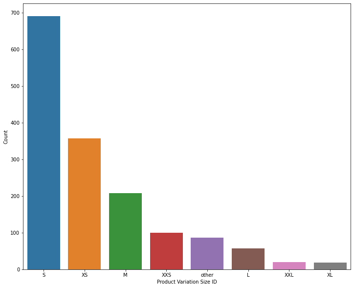

```python
plt.figure(figsize=(12,10))
sns.countplot(x = 'product_variation_size_id', data = df, order = df['product_variation_size_id'].value_counts().iloc[:].index)
plt.xlabel('Product Variation Size ID')
plt.ylabel('Count')
plt.show()
```

### Treat null values of rating_count

In this section we will check the columns:

rating_one_count rating_two_count rating_third_count rating_fourth_count rating_five_count rating rating_count The first 5 columns have missing values. Thee turned out to be products without any rating, altough for some reason the rating of these products is 5, event though they have a rating_count of 0.

For these products, I will change the rating and all the rating counts to 0, indicating that they did not get any votes yet.

```python
df[df['rating_five_count'].isnull()].head()
```

|  | title | title_orig | price | retail_price | currency_buyer | units_sold | uses_ad_boosts | rating | rating_count | rating_five_count | ... | merchant_rating_count | merchant_rating | merchant_id | merchant_has_profile_picture | merchant_profile_picture | product_url | product_picture | product_id | theme | crawl_month |
| --- | --- | --- | --- | --- | --- | --- | --- | --- | --- | --- | --- | --- | --- | --- | --- | --- | --- | --- | --- | --- | --- |
| 74 | Fashion Women Sleeveless Lace Vest Loose V Nec... | Fashion Women Sleeveless Lace Vest Loose V Nec... | 8.00 | 33 | EUR | 10 | 0 | 5.0 | 0 | NaN | ... | 1496 | 4.169786 | 592955ef980a346d826f7bfc | 0 | NaN | https://www.wish.com/c/5ed0dfc51fa8446451b19c0d | https://contestimg.wish.com/api/webimage/5ed0d... | 5ed0dfc51fa8446451b19c0d | summer | 2020-08 |
| 112 | Womens Summer Fashion Lip Print 2pc Set Ladies... | Womens Summer Fashion Lip Print 2pc Set Ladies... | 5.00 | 51 | EUR | 10 | 0 | 5.0 | 0 | NaN | ... | 295 | 3.989831 | 5d464a1ffdf7bc44ee933c65 | 0 | NaN | https://www.wish.com/c/5eb90ab5ad67f63678d15ed9 | https://contestimg.wish.com/api/webimage/5eb90... | 5eb90ab5ad67f63678d15ed9 | summer | 2020-08 |
| 126 | Women's Casual Sleeveless Stripe T Shirts Dres... | Women's Casual Sleeveless Stripe T Shirts Dres... | 2.72 | 9 | EUR | 1 | 0 | 5.0 | 0 | NaN | ... | 378 | 3.597884 | 5d417e7070327a2743021677 | 0 | NaN | https://www.wish.com/c/5ed3ae8e7bf8821d5cf4bc64 | https://contestimg.wish.com/api/webimage/5ed3a... | 5ed3ae8e7bf8821d5cf4bc64 | summer | 2020-08 |
| 189 | Jupe de tennis plissée extensible Active Skort... | Women's Active Skort Athletic Stretchy Pleated... | 5.00 | 5 | EUR | 10 | 0 | 5.0 | 0 | NaN | ... | 129 | 3.837209 | 5a3231f2e62bbc45b0bda1dd | 0 | NaN | https://www.wish.com/c/5ed1c059630f990d1d44592c | https://contestimg.wish.com/api/webimage/5ed1c... | 5ed1c059630f990d1d44592c | summer | 2020-08 |
| 216 | Women's Sexy Push Up Bikini Sexy Vintage Set S... | Women's Sexy Push Up Bikini Vintage Set Sexy B... | 11.00 | 30 | EUR | 10 | 0 | 5.0 | 0 | NaN | ... | 22621 | 4.295124 | 56025ed8293a5b2d24779bde | 0 | NaN | https://www.wish.com/c/573db9316b335c34ca0513b8 | https://contestimg.wish.com/api/webimage/573db... | 573db9316b335c34ca0513b8 | summer | 2020-08 |

5 rows × 43 columns

```python
df['rating_five_count'] = df['rating_five_count'].replace(np.nan, 0)
df['rating_four_count'] = df['rating_four_count'].replace(np.nan, 0)
df['rating_three_count'] = df['rating_three_count'].replace(np.nan, 0)
df['rating_two_count'] = df['rating_two_count'].replace(np.nan, 0)
df['rating_one_count'] = df['rating_one_count'].replace(np.nan, 0)
```

### Treat null values of has_urgency_banner

The column has_urgency_banner has values either 1 or nan, so I will turn the nan values of this column into 0.

```python
df["has_urgency_banner"].unique() #remove the nan
```

```
array([ 1., nan])
```

```python
df['has_urgency_banner'] = df['has_urgency_banner'].replace(np.nan, 0)
```

```python
df.isnull().any()
```

```
title                           False
title_orig                      False
price                           False
retail_price                    False
currency_buyer                  False
units_sold                      False
uses_ad_boosts                  False
rating                          False
rating_count                    False
rating_five_count               False
rating_four_count               False
rating_three_count              False
rating_two_count                False
rating_one_count                False
badges_count                    False
badge_local_product             False
badge_product_quality           False
badge_fast_shipping             False
tags                            False
product_color                   False
product_variation_size_id       False
product_variation_inventory     False
shipping_option_name            False
shipping_option_price           False
shipping_is_express             False
countries_shipped_to            False
inventory_total                 False
has_urgency_banner              False
urgency_text                     True
origin_country                  False
merchant_title                  False
merchant_name                    True
merchant_info_subtitle           True
merchant_rating_count           False
merchant_rating                 False
merchant_id                     False
merchant_has_profile_picture    False
merchant_profile_picture         True
product_url                     False
product_picture                 False
product_id                      False
theme                           False
crawl_month                     False
dtype: bool
```

```python
df['merchant_profile_picture'].value_counts()
```

```
https://s3-us-west-1.amazonaws.com/sweeper-production-merchantimage/dp_5acaf29d5ebcfd72403106a8.jpg    12
https://s3-us-west-1.amazonaws.com/sweeper-production-merchantimage/dp_5533c83986ff95173dc017d0.jpg     8
https://s3-us-west-1.amazonaws.com/sweeper-production-merchantimage/dp_55c8a4c33a698c6010edcd9e.jpg     6
https://s3-us-west-1.amazonaws.com/sweeper-production-merchantimage/dp_58ad449708de0c6dc59d9e06.jpg     5
https://s3-us-west-1.amazonaws.com/sweeper-production-merchantimage/dp_5268759b736046671957190c.jpg     5
                                                                                                       ..
https://s3-us-west-1.amazonaws.com/sweeper-production-merchantimage/dp_5542fcb264b4f014ce88ecae.jpg     1
https://s3-us-west-1.amazonaws.com/sweeper-production-merchantimage/dp_57fcc26f1c813a50b2a86956.jpg     1
https://s3-us-west-1.amazonaws.com/sweeper-production-merchantimage/dp_53bd3edad911396c5b3fb0aa.jpg     1
https://s3-us-west-1.amazonaws.com/sweeper-production-merchantimage/dp_57973560cb38dd77d126e9f1.jpg     1
https://s3-us-west-1.amazonaws.com/sweeper-production-merchantimage/dp_57713183bd6b18740117229d.jpg     1
Name: merchant_profile_picture, Length: 125, dtype: int64
```

merchant_profile_picture contains the url to merchants profile picture where more than 80% of data is missing

### Unit Sold Data Analysis

```python
pr_unit = df['units_sold'].value_counts()
pr_unit
```

```
100       493
1000      403
5000      216
10000     176
20000     103
50         68
10         44
50000      17
100000      6
8           3
1           3
7           2
3           2
2           2
6           1
Name: units_sold, dtype: int64
```

```python
def pr_units(item):
    if item == 10 \
    or item == 50 \
    or item == 100 \
    or item == 1000 \
    or item == 5000 \
    or item == 10000 \
    or item == 20000 \
    or item == 50000 \
    or item == 100000:
        return item
    else:
        return 10

df['units_sold'] = df['units_sold'].apply(pr_units)
pr_unit = df['units_sold'].value_counts()
pr_unit
```

```
100       493
1000      403
5000      216
10000     176
20000     103
50         68
10         57
50000      17
100000      6
Name: units_sold, dtype: int64
```

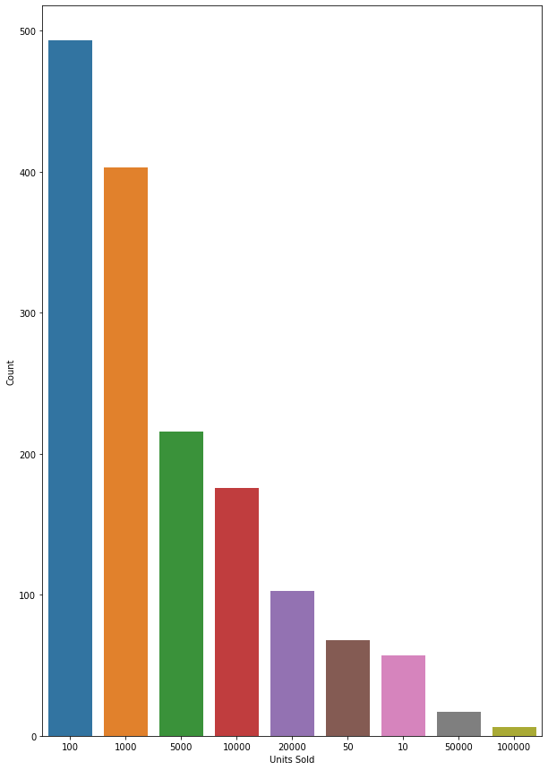

```python
fig_dims = (10, 15)
fig, ax = plt.subplots(figsize=fig_dims)
sns.countplot('units_sold',
              data = df,
              order = df['units_sold'].value_counts().index,
              ax = ax)
ax.set(xlabel='Units Sold', ylabel='Count')
plt.show()
```

```python
df.info()
```

```
<class 'pandas.core.frame.DataFrame'>
Int64Index: 1539 entries, 0 to 1572
Data columns (total 43 columns):
 #   Column                        Non-Null Count  Dtype
---  ------                        --------------  -----
 0   title                         1539 non-null   object
 1   title_orig                    1539 non-null   object
 2   price                         1539 non-null   float64
 3   retail_price                  1539 non-null   int64
 4   currency_buyer                1539 non-null   object
 5   units_sold                    1539 non-null   int64
 6   uses_ad_boosts                1539 non-null   int64
 7   rating                        1539 non-null   float64
 8   rating_count                  1539 non-null   int64
 9   rating_five_count             1539 non-null   float64
```

[output cut: 35 more lines]

### Create new columns for better understanding

```python
df['product_discount'] = df['retail_price'] - df['price']
#shows how much the product was discounted.
```

```python
df['product_discount%'] = (df['retail_price'] - df['price'])/df['retail_price']*100
# shows the % of discount applied on the product
```

```python
df['discount_amt_range'] = pd.cut(df['product_discount'], bins=np.arange(-10, 260, 10), right=False)

df['discount_prct_range'] = pd.cut(df['product_discount%'], bins=np.arange(-20, 110, 10), right=False)
```

### Making sense of the Tags

```python
# Lets check the proportion of top 20 tags count
category_data = pd.read_csv('/Users/malkani/desktop/project/Ecommerce wish/unique-categories.sorted-by-count.csv')
(category_data['count'].head(20).sum() / category_data['count'].sum())*100
```

```
41.0016450374703
```

Since top 20 tags are 41% of total tags lets replace by making a bag of words string from those top 20 tags

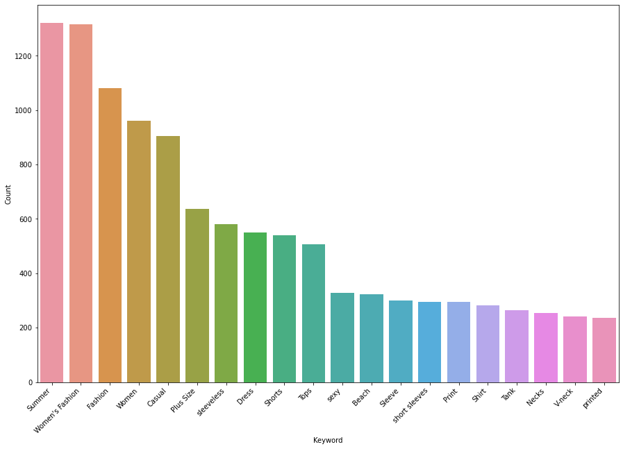

```python
fig_dims = (15, 10)
fig, ax = plt.subplots(figsize=fig_dims)
sns.barplot(x = 'keyword',
            y = 'count',
            data = category_data.iloc[:20],
            ax = ax)
ax.set(xlabel='Keyword', ylabel='Count')
plt.xticks(rotation=45, ha='right')
plt.show()
```

### Now let's create a column which indicates how many popular tags contain on a specific product tag

```python
pop_tags = category_data.iloc[:10]['keyword'].tolist()

def check_tag_quality(tags):
    tag_str = tags
    prod_tags = tag_str.split(',')

    common_elements = np.intersect1d(pop_tags, prod_tags)
    return len(common_elements) / len(pop_tags)

df['tag_quality'] = df['tags'].apply(check_tag_quality)
df['tag_quality']
```

```
0       0.7
1       0.5
2       0.3
3       0.6
4       0.6
       ...
1568    0.7
1569    0.5
1570    0.2
1571    0.6
1572    0.4
Name: tag_quality, Length: 1539, dtype: float64
```

### Check the number of tags include in the product

```python
def tag_count(tags):
    tag_str = tags
    prod_tags = tag_str.split(',')
    return len(prod_tags)

df['tag_count'] = df['tags'].apply(tag_count)
df['tag_count']
```

```
0       24
1       15
2       19
3       18
4       13
        ..
1568    24
1569    18
1570    12
1571    21
1572    12
Name: tag_count, Length: 1539, dtype: int64
```

### Check whether the title was localised or not

```python
def is_localised(trans,origi):
    if trans == origi:
        return 0
    else:
        return 1

df['title_localised'] = df.apply(lambda x: is_localised(x.title, x.title_orig),
                                               axis = 1)
df['title_localised']
```

```
0       0
1       1
2       1
3       1
4       1
       ..
1568    1
1569    1
1570    1
1571    1
1572    1
Name: title_localised, Length: 1539, dtype: int64
```

### Check Merchant title and Merchant name

```python
def check_name(title,name):
    title = str(title).replace(" ", "")
    title = title.replace(".", "")

    name = str(name).replace(" ", "")
    name = name.replace(".", "")

    if title.lower() == name.lower():
        return 1
    else:
        return 0

df['com_same_name'] = df.apply(lambda x: check_name(x.merchant_title, x.merchant_name),
                                             axis = 1)
df['com_same_name']
```

```
0       1
1       1
2       1
3       1
4       0
       ..
1568    1
1569    1
1570    1
1571    1
1572    1
Name: com_same_name, Length: 1539, dtype: int64
```

### Check whether the merchant subtitle contains postive ratings

```python
def inc_positive_per(wordset):
    pos_ses = 'avis positifs'
    if f'{pos_ses}' in f'{wordset}':
        return 1
    else:
        return 0

df['subtitle_rating'] = df['merchant_info_subtitle'].apply(inc_positive_per)
```

```python
def check_rating_prop(s_count,t_count):
    if s_count == 0:
        return 0
    else:
        return s_count/t_count

df['rating_five_count'] = df.apply(lambda x: check_rating_prop(x.rating_five_count, x.rating_count),
                                             axis = 1)
df['rating_four_count'] = df.apply(lambda x: check_rating_prop(x.rating_four_count, x.rating_count),
                                             axis = 1)
df['rating_three_count'] = df.apply(lambda x: check_rating_prop(x.rating_three_count, x.rating_count),
                                             axis = 1)
df['rating_two_count'] = df.apply(lambda x: check_rating_prop(x.rating_two_count, x.rating_count),
                                             axis = 1)
df['rating_one_count'] = df.apply(lambda x: check_rating_prop(x.rating_one_count, x.rating_count),
                                             axis = 1)
```

```python
def merchant_pop_on_prod(m_count,p_count):
    if m_count == 0:
        return 0
    else:
        return p_count / m_count

df['merch_pop_proc'] = df.apply(lambda x: merchant_pop_on_prod(x.merchant_rating_count, x.rating_count),
                                              axis = 1)
```

```python
df.to_csv('Clean_Eproduct_Data.csv')
```

1.There are some cases where the price is low still the units sold are below average, possible reasons the product might not be upto the mark as per the buyers or there are some other factors affecting the price we haven't touched yet

2.Median of units sold is 1000, by this we can consider that products with units sold below 1000 (inclusive) were below average and products with units sold are very successfull. # It totally depends on your business goals which price range you want to focus on.

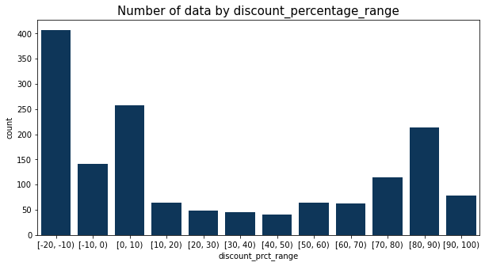

```python
plt.subplots(figsize=(10,5))
sns.countplot(x='discount_prct_range', data=df, order=sorted(df['discount_prct_range'].unique()),palette= ["#013766"])
plt.title('Number of data by discount_percentage_range', fontsize=15)
plt.show()
```

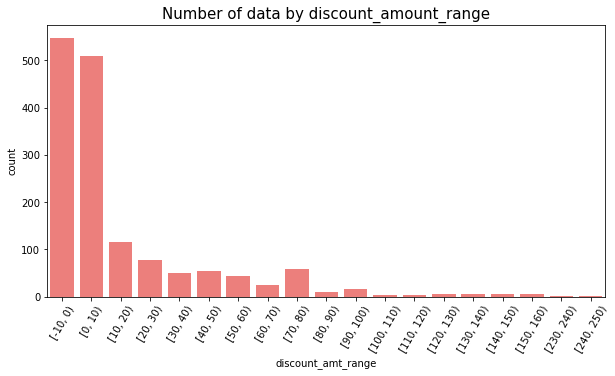

```python
plt.subplots(figsize=(10,5))
sns.countplot(x='discount_amt_range', data=df, order=sorted(df['discount_amt_range'].unique()),palette= ["#ff6d69"])
plt.xticks(rotation=60)
plt.title('Number of data by discount_amount_range', fontsize=15)
plt.show()
```

### Correlation Heat Map

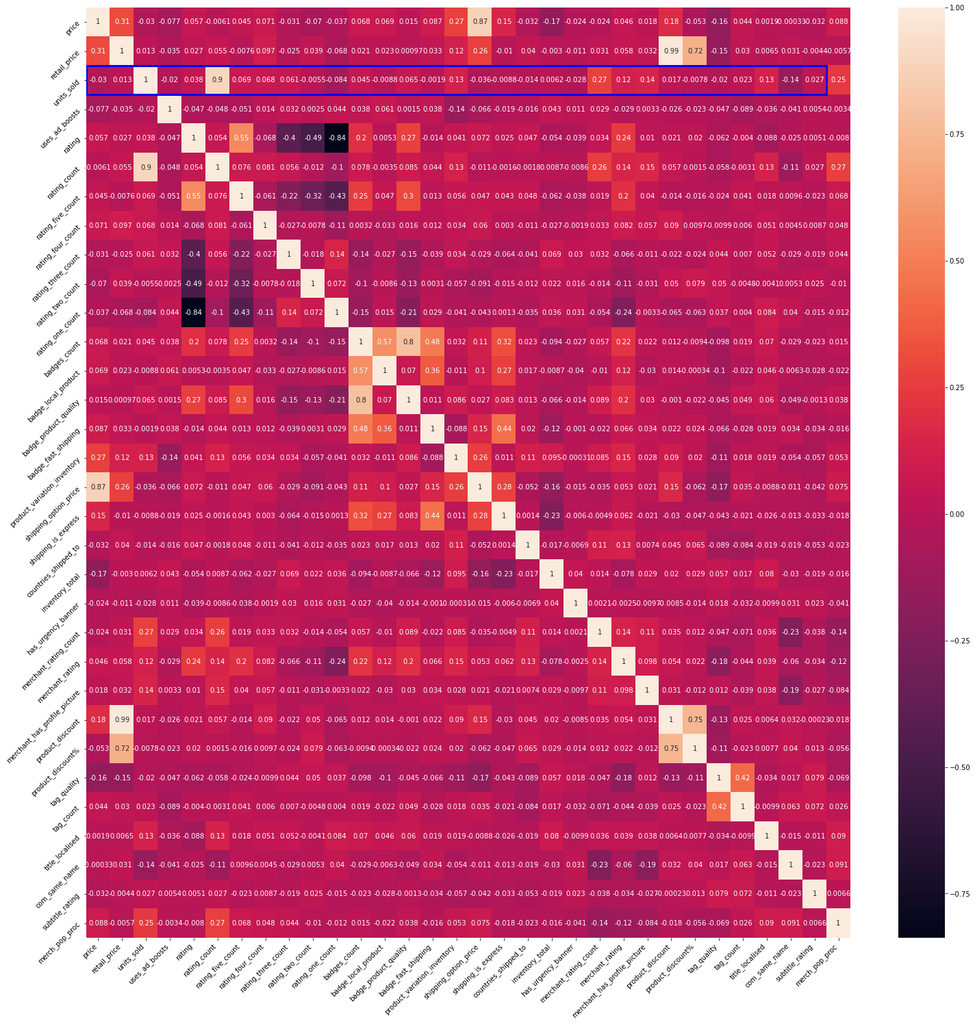

```python
fig_dims = (25, 25)
fig, ax = plt.subplots(figsize=fig_dims)
sns.heatmap(df.corr(),
            annot=True,
            ax=ax)
ax.add_patch(plt.Rectangle((0,2),31,1,
                           fill = False,
                           edgecolor = 'blue',
                           lw = 3))
plt.xticks(rotation=45, ha='right')
plt.yticks(rotation=45, ha='right')
plt.show()
```

Special Note :-

Add Boost does not have any significant change to the 'units_sold'

```python
def get_pairs(df, trgt_col):
    '''Get diagonal and lower triangular pairs of correlation matrix'''
    pairs_to_drop = set()
    cols = df.columns
    for i in range(0, df.shape[1]):
        pairs_to_drop.add((trgt_col, cols[i]))
    return pairs_to_drop

def get_strong_correlations(df, n=10):
    au_corr = df.corr().unstack()
    labels_to_drop = get_pairs(df, 'units_sold')
    au_corr_desc = au_corr['units_sold'].sort_values(ascending=False)
    au_corr_asc = au_corr['units_sold'].sort_values(ascending=True)
    return au_corr_desc[0:n], au_corr_asc[0:n]

au_corr_desc, au_corr_asc = get_strong_correlations(df, 15)

print("Strong Correlations")
print("Positive Correlations")
print(au_corr_desc)
print(au_corr_desc.index)
print('-----------------------------')
print("Negative Correlations")
print(au_corr_asc)
```

```
Strong Correlations
Positive Correlations
units_sold                      1.000000
rating_count                    0.899084
merchant_rating_count           0.272282
merch_pop_proc                  0.245523
merchant_has_profile_picture    0.141371
product_variation_inventory     0.130508
title_localised                 0.127417
merchant_rating                 0.119660
rating_five_count               0.068655
rating_four_count               0.068318
badge_product_quality           0.064749
rating_three_count              0.061330
badges_count                    0.045488
rating                          0.038380
subtitle_rating                 0.026628
dtype: float64
Index(['units_sold', 'rating_count', 'merchant_rating_count', 'merch_pop_proc',
       'merchant_has_profile_picture', 'product_variation_inventory',
       'title_localised', 'merchant_rating', 'rating_five_count',
       'rating_four_count', 'badge_product_quality', 'rating_three_count',
       'badges_count', 'rating', 'subtitle_rating'],
      dtype='object')
-----------------------------
Negative Correlations
com_same_name           -0.140582
rating_one_count        -0.084442
shipping_option_price   -0.036367
price                   -0.029631
has_urgency_banner      -0.028269
uses_ad_boosts          -0.020199
tag_quality             -0.019679
countries_shipped_to    -0.013825
badge_local_product     -0.008789
shipping_is_express     -0.008778
product_discount%       -0.007838
rating_two_count        -0.005535
badge_fast_shipping     -0.001916
inventory_total          0.006245
retail_price             0.012926
dtype: float64
```

### Remove Unwanted Columns

rating_count parameter is a driving factor for the unit_sold. It's obvious that rating_count increases the model accuracy. Since the model is predicting future sales we do not know rating_count for the model.

merchant could buy enough stock to maximise the revenue or stop buying way too much of a product. So the below model could be used, If the merchant has some data about the first few weeks of sales.

Columns: title, title_orig, merchant_profile_picture, product_url, product_picture, product_id, merchant_id, merchant_info_subtitle, merchant_name, merchant_title, shipping_option_name, urgency_text

These will be dropped for now, as the likelihood of these affecting the number of units sold is pretty less. For some of the features present above, a corresponding feature already exists in the dataset that provides more information relevant to the model we want to make.

The rating count column will also be removed for now as we already have features of the distribution of rating count across (5/4/3/2/1) which gives us a more detailed information than 'rating count'

```python
df.info()
```

```
<class 'pandas.core.frame.DataFrame'>
Int64Index: 1539 entries, 0 to 1572
Data columns (total 53 columns):
 #   Column                        Non-Null Count  Dtype
---  ------                        --------------  -----
 0   title                         1539 non-null   object
 1   title_orig                    1539 non-null   object
 2   price                         1539 non-null   float64
 3   retail_price                  1539 non-null   int64
 4   currency_buyer                1539 non-null   object
 5   units_sold                    1539 non-null   int64
 6   uses_ad_boosts                1539 non-null   int64
 7   rating                        1539 non-null   float64
 8   rating_count                  1539 non-null   int64
 9   rating_five_count             1539 non-null   float64
```

[output cut: 45 more lines]

```python
df = df.drop(['crawl_month','product_id','product_picture', 'product_url', 'merchant_profile_picture', 'merchant_id', 'currency_buyer'], axis = 1)
df = df.drop(['theme','urgency_text', 'merchant_title', 'merchant_name', 'merchant_info_subtitle'], axis = 1)
df = df.drop(['title','title_orig','tags'], axis = 1)
df = df.drop(['shipping_option_name'], axis = 1)
df = df.drop(['rating_count'], axis = 1)
df = df.drop(['discount_amt_range','discount_prct_range'],axis = 1) #categorical
```

```python
df.info()
```

```
<class 'pandas.core.frame.DataFrame'>
Int64Index: 1539 entries, 0 to 1572
Data columns (total 34 columns):
 #   Column                        Non-Null Count  Dtype
---  ------                        --------------  -----
 0   price                         1539 non-null   float64
 1   retail_price                  1539 non-null   int64
 2   units_sold                    1539 non-null   int64
 3   uses_ad_boosts                1539 non-null   int64
 4   rating                        1539 non-null   float64
 5   rating_five_count             1539 non-null   float64
 6   rating_four_count             1539 non-null   float64
 7   rating_three_count            1539 non-null   float64
 8   rating_two_count              1539 non-null   float64
 9   rating_one_count              1539 non-null   float64
```

[output cut: 26 more lines]

### Create Model to predict Units Sold

```python
df = pd.get_dummies(df,
                           columns = ['product_color'],
                           prefix = 'color_',
                           drop_first = True)
df.head()
```

[output not shown]

5 rows × 110 columns

```python
df = pd.get_dummies(df,
                        columns = ['product_variation_size_id'],
                        prefix = 'size_',
                        drop_first = True)
df.head()
```

[output not shown]

5 rows × 116 columns

```python
df = pd.get_dummies(df,
                           columns = ['origin_country'],
                           prefix = 'country_',
                           drop_first = True)
df.info()
```

```
<class 'pandas.core.frame.DataFrame'>
Int64Index: 1539 entries, 0 to 1572
Columns: 117 entries, price to country__US
dtypes: float64(13), int64(18), uint8(86)
memory usage: 554.0 KB
```

```python
from sklearn.model_selection import train_test_split

r_state = 3
X = df.drop(['units_sold'], axis = 1)
y = df['units_sold']

X_train, X_test, y_train, y_test = train_test_split(X, y,
                                                    test_size = 0.2,
                                                    random_state = r_state)
```

```python
df.info()
```

```
<class 'pandas.core.frame.DataFrame'>
Int64Index: 1539 entries, 0 to 1572
Columns: 117 entries, price to country__US
dtypes: float64(13), int64(18), uint8(86)
memory usage: 554.0 KB
```

```python
from sklearn.metrics import confusion_matrix, accuracy_score
from sklearn.tree import DecisionTreeClassifier
from sklearn.metrics import r2_score

classifier_DTC = DecisionTreeClassifier(random_state = r_state)
classifier_DTC.fit(X_train, y_train)

y_pred_DTC = classifier_DTC.predict(X_test)
accuracy_score(y_test, y_pred_DTC)
```

```
0.6525974025974026
```

```python
from sklearn.svm import SVC

classifier_SVC = SVC(random_state = r_state)
classifier_SVC.fit(X_train, y_train)

y_pred_SVC = classifier_SVC.predict(X_test)
accuracy_score(y_test, y_pred_SVC)
```

```
0.32142857142857145
```

```python
from sklearn.ensemble import AdaBoostClassifier

classifier_ABC = AdaBoostClassifier(learning_rate = 0.01,
                                   random_state = r_state) # Default using Decision Tree Classifier
classifier_ABC.fit(X_train, y_train)

y_pred_ABC = classifier_ABC.predict(X_test)
accuracy_score(y_test, y_pred_ABC)
```

```
0.32792207792207795
```

```python
from sklearn.ensemble import RandomForestClassifier

classifier_RFC = RandomForestClassifier(random_state = r_state)
classifier_RFC.fit(X_train, y_train)

y_pred_RFC = classifier_RFC.predict(X_test)
accuracy_score(y_test, y_pred_RFC)
```

```
0.6266233766233766
```

```python
classifier_ABC_RF = AdaBoostClassifier(RandomForestClassifier(random_state = r_state),
                                       learning_rate = 0.01,
                                       random_state = r_state)
classifier_ABC_RF.fit(X_train, y_train)

y_pred_ABC_RF = classifier_ABC_RF.predict(X_test)
accuracy_score(y_test, y_pred_ABC_RF)
```

```
0.6136363636363636
```

```python
from sklearn.ensemble import GradientBoostingClassifier

classifier_GBC = GradientBoostingClassifier(random_state = r_state)
classifier_GBC.fit(X_train, y_train)

y_pred_GBC = classifier_GBC.predict(X_test)
accuracy_score(y_test, y_pred_GBC)
```

```
0.6753246753246753
```

```python
from sklearn.neighbors import KNeighborsClassifier

classifier_KNN = KNeighborsClassifier(n_neighbors = 5)
classifier_KNN.fit(X_train, y_train)

y_pred_KNN = classifier_KNN.predict(X_test)
accuracy_score(y_test, y_pred_KNN)
```

```
0.3344155844155844
```

```python
from sklearn.model_selection import cross_val_score

classifiers = [classifier_DTC,
               classifier_SVC,
               classifier_ABC,
               classifier_RFC,
               classifier_ABC_RF,
               classifier_GBC,
               classifier_KNN,]
classifiers_names = ['Decision Tree',
                     'SVC',
                     'AdaBoost',
                     'Random Forest',
                     'AdaBoost - Random Forest',
                     'Gradient Boosting',
                     'KNeighborsClassifier',]
accuracy_mean = []
for cl in classifiers :
    accuracies = cross_val_score(estimator = cl,
                                 X = X_train,
                                 y = y_train,
                                 cv = 4)
    accuracy_mean.append(accuracies.mean()*100)


accuracy_df = pd.DataFrame({'Classifier': classifiers_names,
                           'Accuracy Mean': accuracy_mean})
accuracy_df.sort_values('Accuracy Mean',ascending=False)
```

|  | Classifier | Accuracy Mean |
| --- | --- | --- |
| 5 | Gradient Boosting | 66.532002 |
| 0 | Decision Tree | 60.602712 |
| 3 | Random Forest | 57.836890 |
| 4 | AdaBoost - Random Forest | 56.048796 |
| 1 | SVC | 34.278629 |
| 2 | AdaBoost | 33.386565 |
| 6 | KNeighborsClassifier | 30.948856 |